# EVAR practice and outcomes since 1996

Martin Hennessy

21/07/2019

# 1 Details about all EVARs performed

- This document covers EVARs performed between 1996-09-19 and 2019-06-26
- This comprises 875 EVARs

## 1.1 Indication

### 1.1.1 Number of EVAR for each indication

- Both ruptured and symptomatic aneurysms are judged by available clinical information
- Open repair issue is usually pseudoaneurysm formation

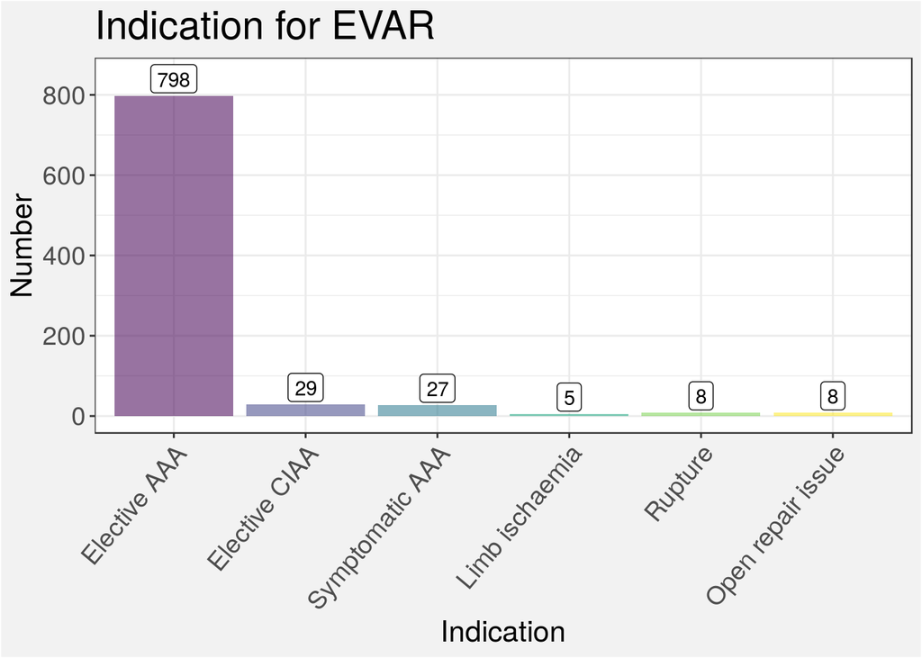

## 1.2 Site

### 1.2.1 Numbers of EVAR at each site

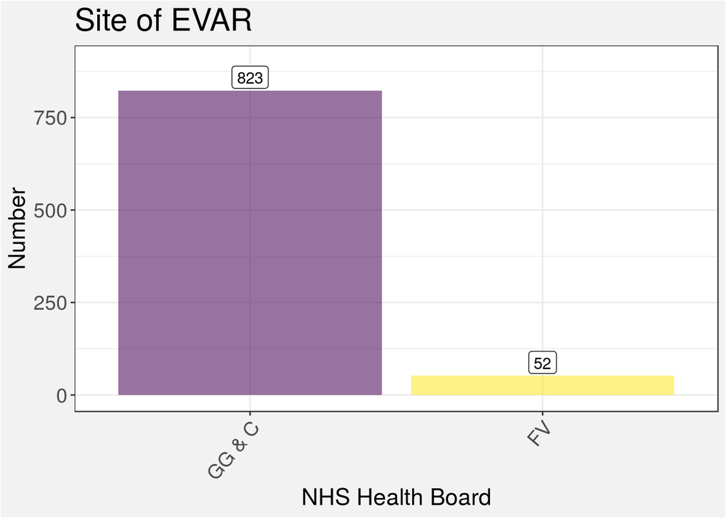

All years; FV = Forth Valley, GG & C = Greater Glasgow and Clyde

### 1.2.2 Numbers of EVAR for each indication at each site

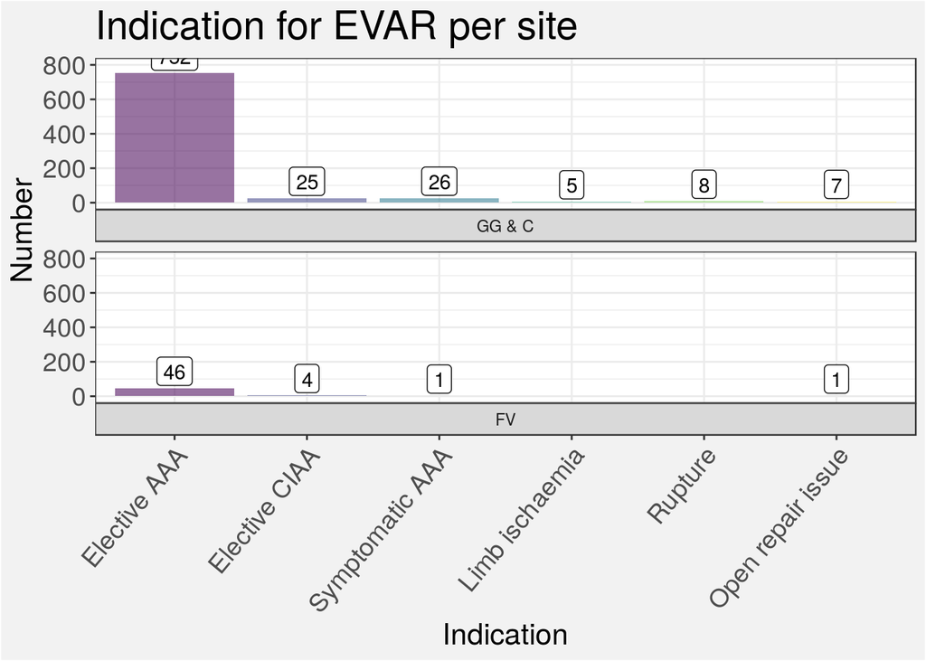

All years, all indications

## 1.3 Gender

### 1.3.1 Number of EVARs performed by gender

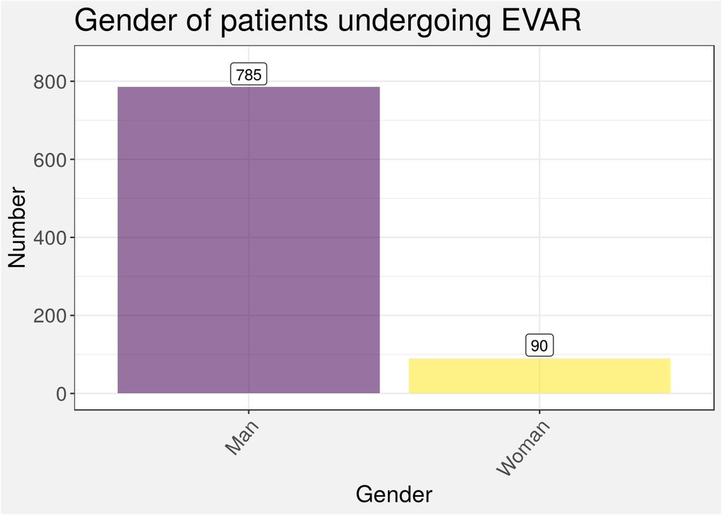

All sites, all years, all indications

## 1.4 Year

### 1.4.1 Number of EVARs performed each year

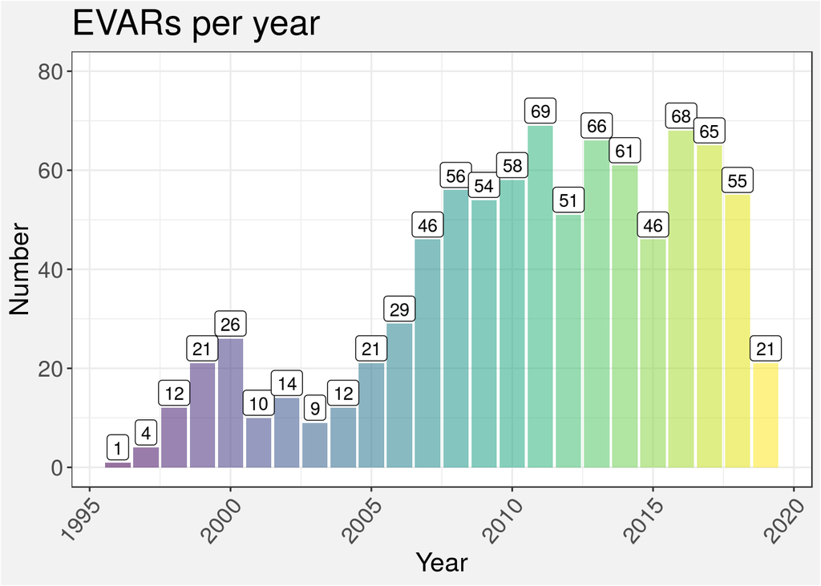

All sites, all indications

## 1.5 Year Group

- To visualise the data about years a different way, the data are grouped into ‘year groups’ of five years, eg. 2010-2014, 2015-2019 etc

### 1.5.1 Number of EVARs performed in each year group

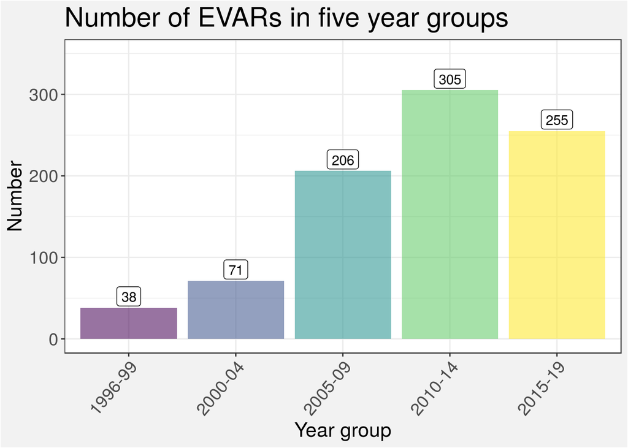

All sites, all indications

# 2 Details about elective EVARs performed

- Subsections below relate to EVARs performed for elective abdominal aortic aneurysms only

## 2.1 Number of elective EVARs

- 798 elective EVARs have been performed in all sites

## 2.2 Site

### 2.2.1 Number of elective EVARs at each site

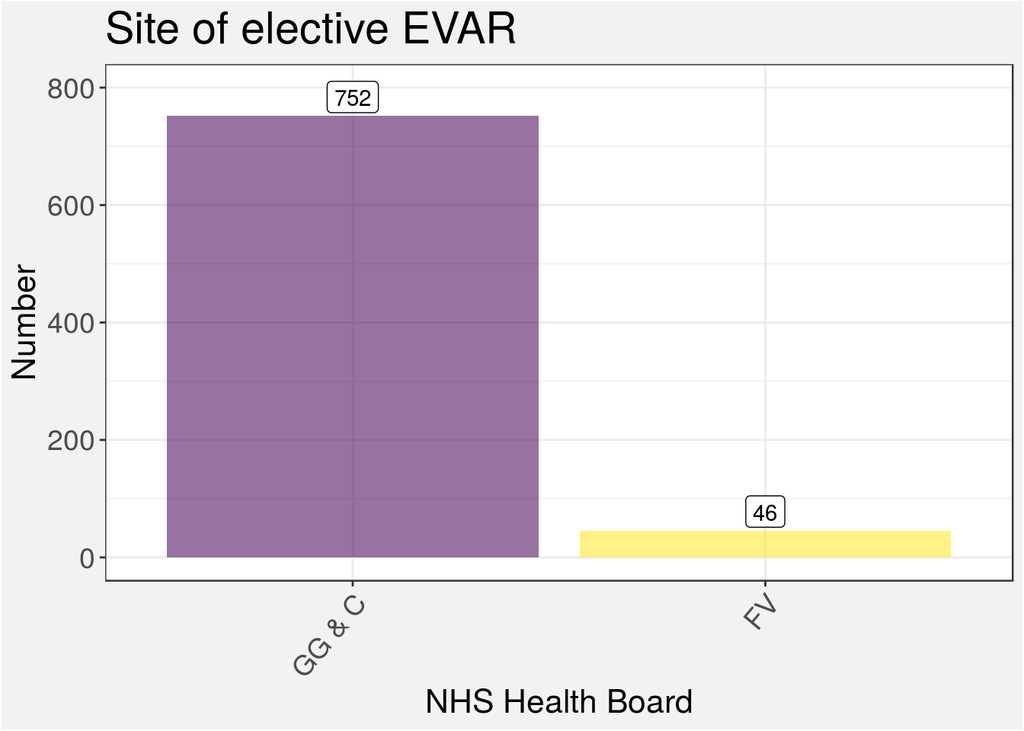

Elective EVARs, all years; FV = Forth Valley, GG & C = Greater Glasgow and Clyde

## 2.3 Gender

### 2.3.1 Number of elective EVARs by gender

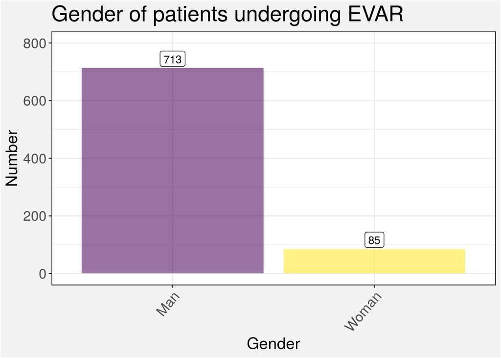

Elective EVARs; all sites, all years

### 2.3.2 Number of elective EVARs performed by gender of patients at each site

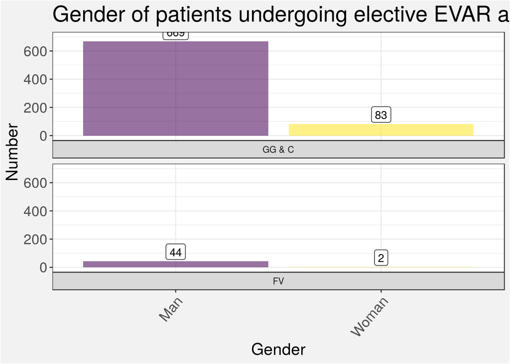

Number of elective EVARs performed, split between men and women, separated by site

## 2.4 Age

### 2.4.1 Age of patients undergoing elective EVAR

- A barplot displaying the number of patients undergoing elective EVAR at each age:

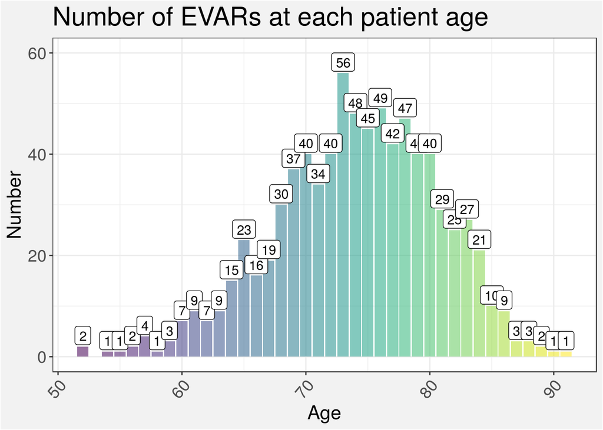

Elective EVARs; all sites, all years

- Median and mean ages for elective EVARs:

| Median | Mean |
| --- | --- |
| 74 | 74.1 |

- Age expressed as a boxplot:

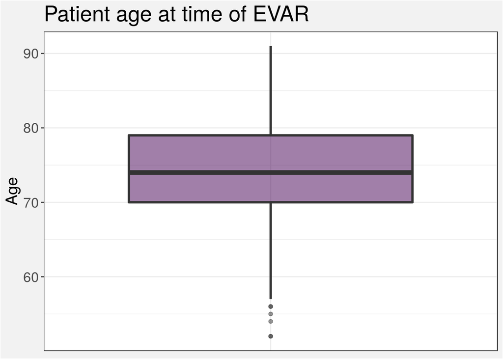

Elective EVARs; all sites, all years

### 2.4.2 Age of patients at each site

- Boxplot of age at each site:

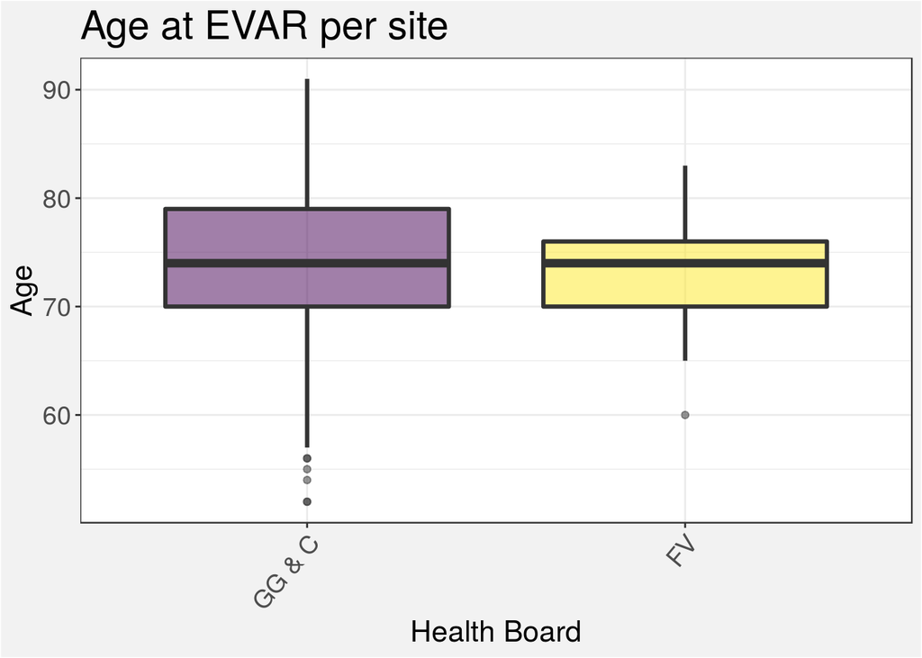

Elective EVARs; all years

- Median and mean age at each site:

| Site | Median | Mean |
| --- | --- | --- |
| GG & C | 74 | 74.2 |
| FV | 74 | 73.5 |

### 2.4.3 Age of patients by gender

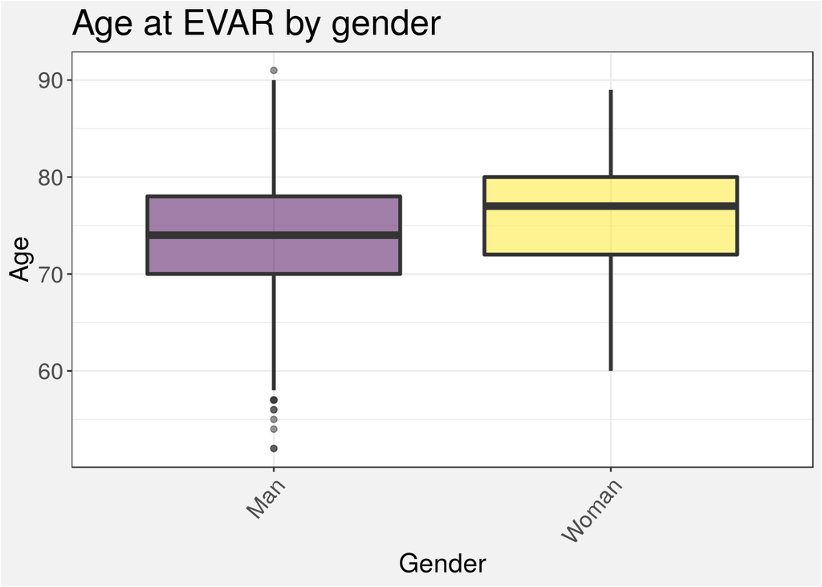

Elective EVARs; all sites, all years

- Median and mean age by gender:

| Gender | Median | Mean |
| --- | --- | --- |
| Man | 74 | 73.9 |
| Woman | 77 | 75.9 |

### 2.4.4 Age of patients undergoing elective EVAR by decade of life

- The number of elective EVARs by age of patient, grouped by decade of life:

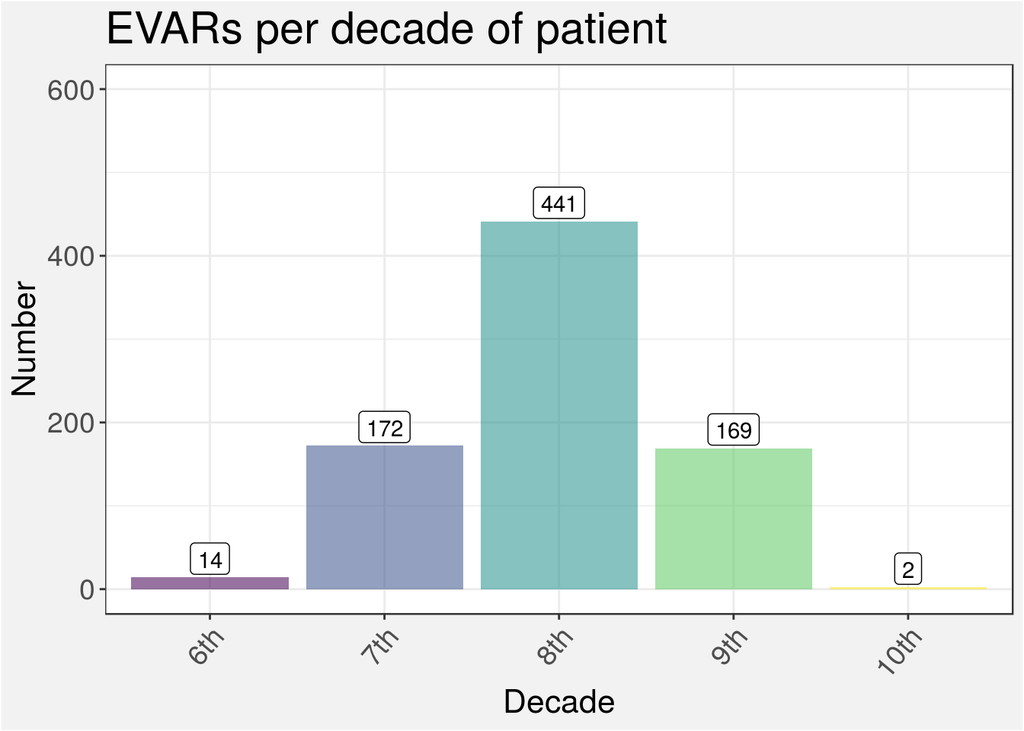

Elective EVARs; all sites, all years

- Due to the small number of patients, those who were in their 6th or 10th decades at time of elective EVAR are ommitted from the following.
- Boxplot of spread of ages in 7th, 8th or 9th decade:

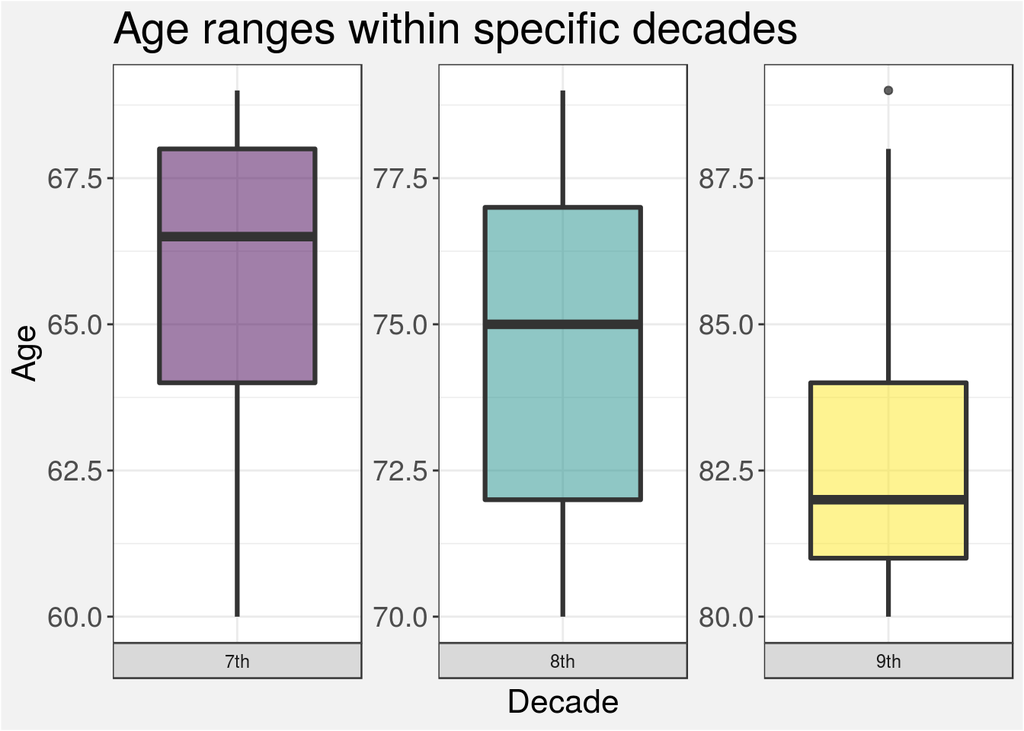

All sites, all years

- Patients in their 7th decade skew slightly towards the upper aspect of that decade
- Patients in their 8th decade, the decade in which most elective EVARs are performed, are evenly spread
- Patients in their 9th decade skew greatly towards the young ages of that decade
- The median and means from the above boxplot are shown in this table:

| Decade | Median | Mean |
| --- | --- | --- |
| 7th | 66.5 | 66.0 |
| 8th | 75.0 | 74.6 |
| 9th | 82.0 | 82.4 |

## 2.5 Year

### 2.5.1 Number of elective EVARs each year

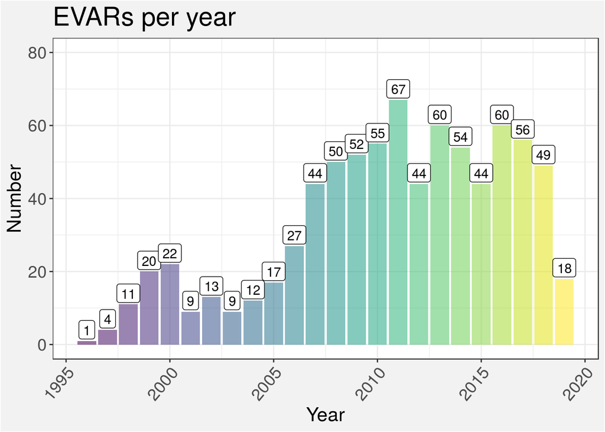

Elective EVARs; all sites

### 2.5.2 Number of elective EVARs each year at each site

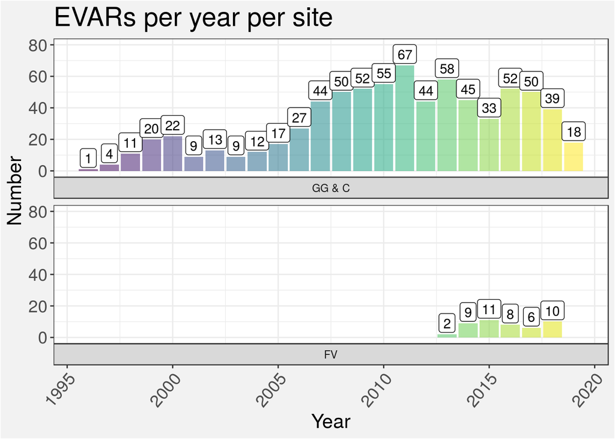

Elective EVARs

### 2.5.3 Age of patients having elective EVAR each year

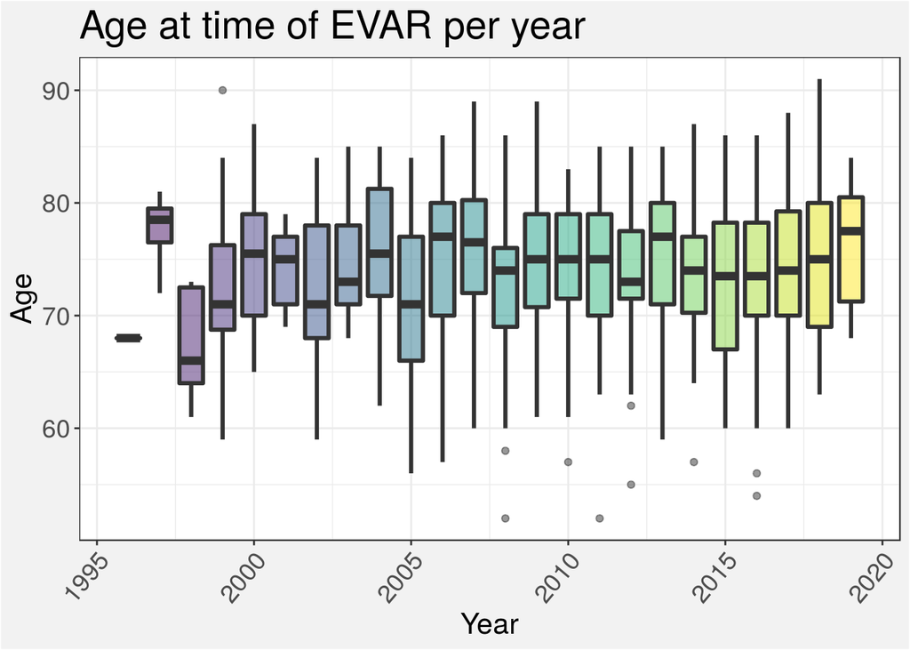

Elective EVARs; all sites

## 2.6 Year Group

### 2.6.1 Number of elective EVARs performed in each year group

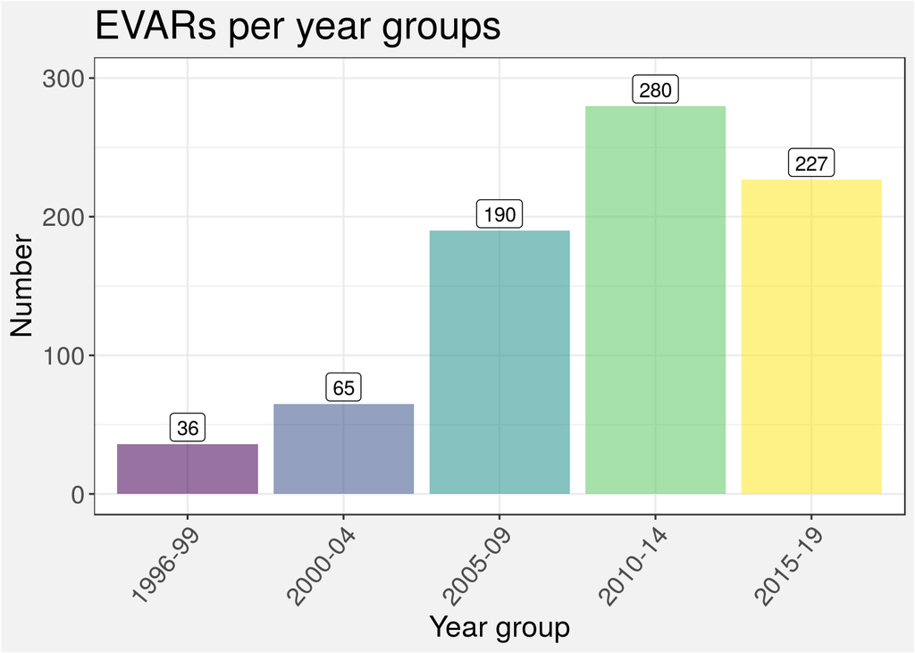

Elective EVARs; all sites

### 2.6.2 Number of elective EVARs performed in each year group at each site

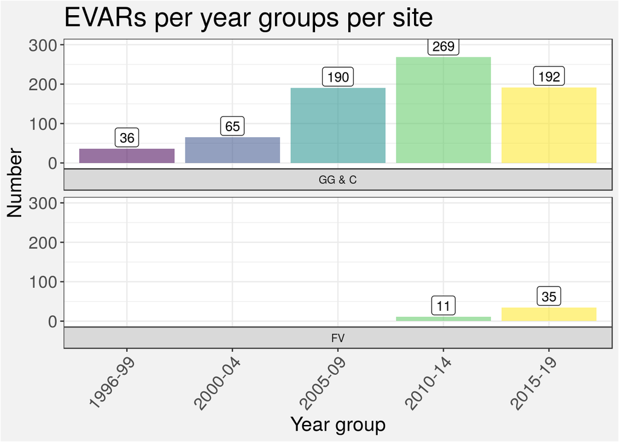

Elective EVARs

## 2.7 Stent-graft

### 2.7.1 Number of stent-grafts used for elective EVAR across all sites

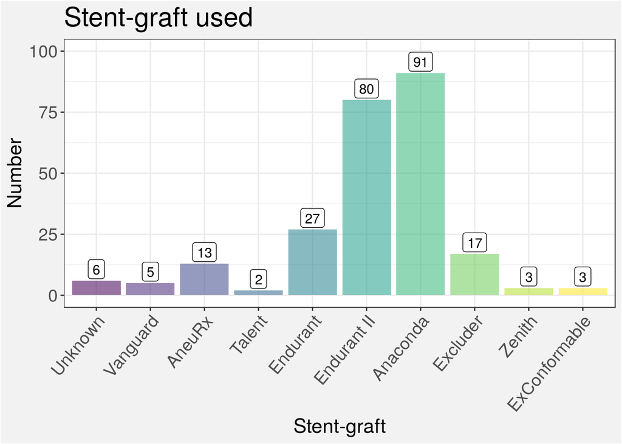

Elective EVARs; all sites, all years

### 2.7.2 Number of stent-grafts used for elective EVAR at each site

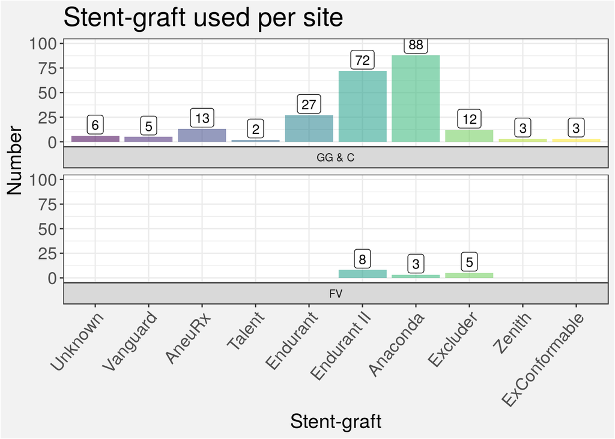

Elective EVARs; all years

### 2.7.3 Number of stent-grafts used for elective EVAR each year

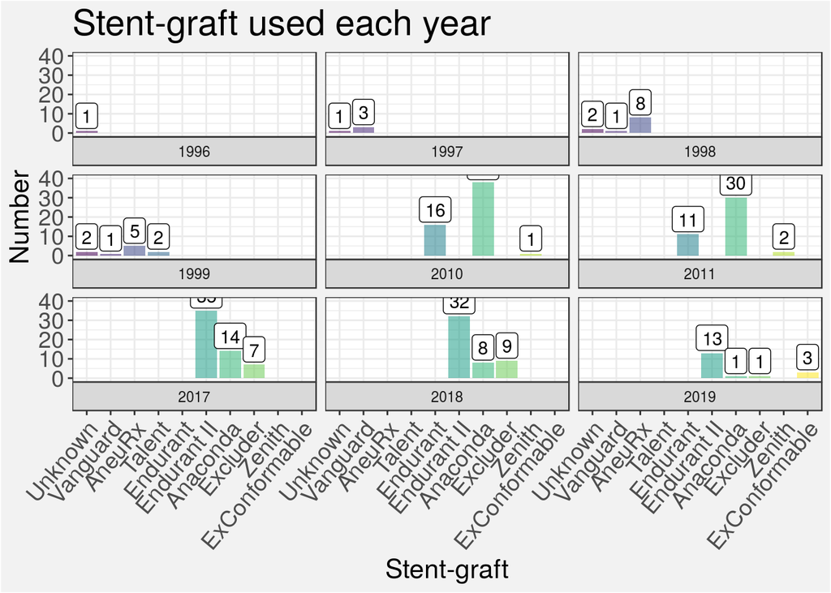

Elective EVARs; all sites

### 2.7.4 Number of stent-grafts used for elective EVAR each year group

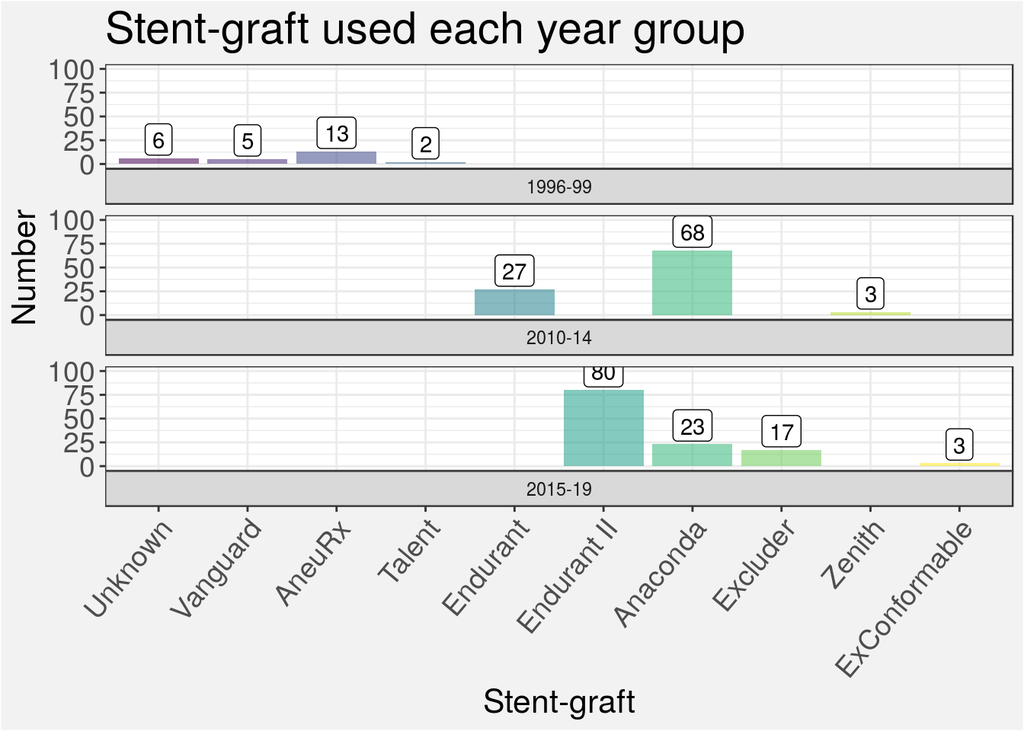

Elective EVARs; all sites

## 2.8 Seal zones and complexity

- This section deals with seal zones for performed EVARs
- Supra-renal seals comprises fEVAR and chEVAR
- For the iliacs, CIA = common iliac artery, EIA = external iliac artery, AUI = aorto-uni-iliac device, IBD = iliac branch device
- For AUI, the side where AUI is recorded is the **occluded** side (the contralateral side could be CIA, EIA etc.)
- For IBD, seal in EIA is assumed

### 2.8.1 Aortic seal zones for elective EVAR across all sites

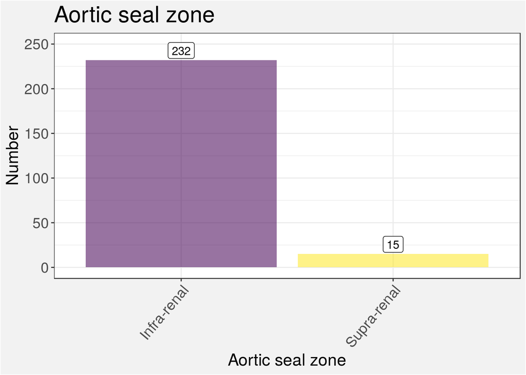

Elective EVARs; all sites, all years

### 2.8.2 Aortic seal zones for elective EVAR for each site

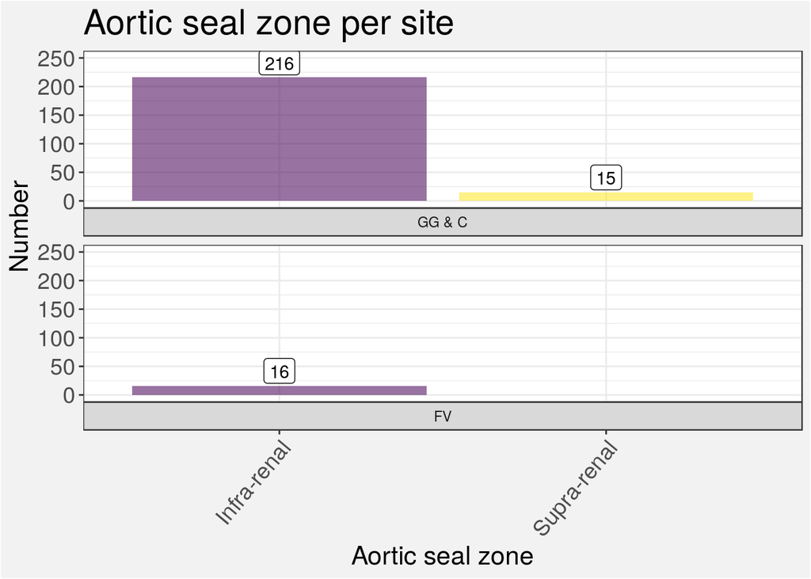

Elective EVARs; all years

### 2.8.3 Iliac seal zone for elective EVAR across all sites

#### 2.8.3.1 All iliacs

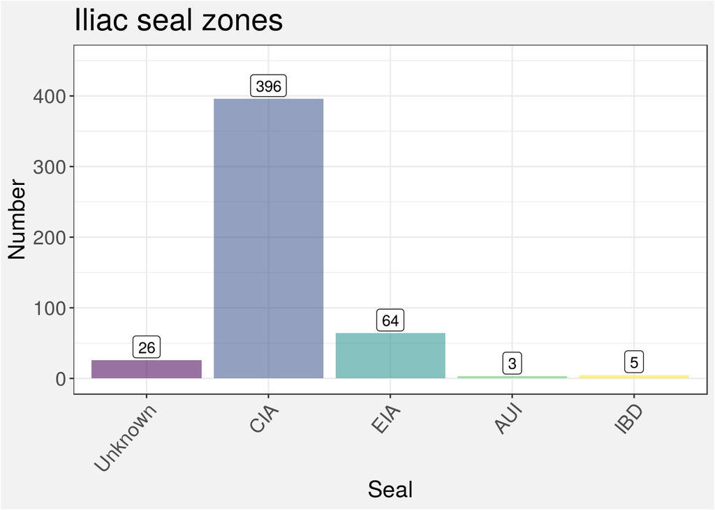

Elective EVARs; all sites, all years

#### 2.8.3.2 Left and right iliacs plotted separately

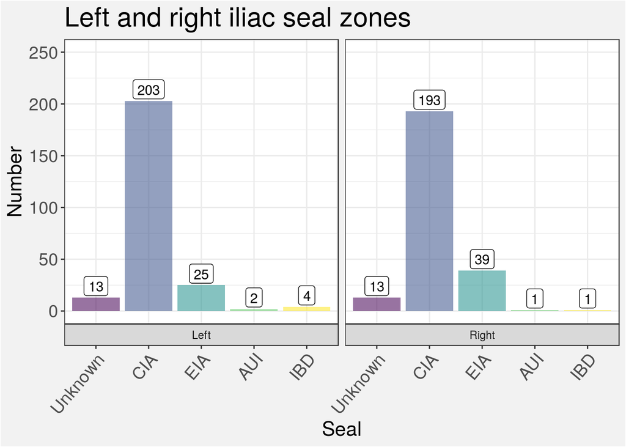

Elective EVARs; all sites, all years

### 2.8.4 Complexity of EVAR

- EVAR is considered complex if supra-renal fixation was used (fEVAR of chEVAR) or if an iliac branch device was used
- Any other factors regarding complexity have not been taken in to account

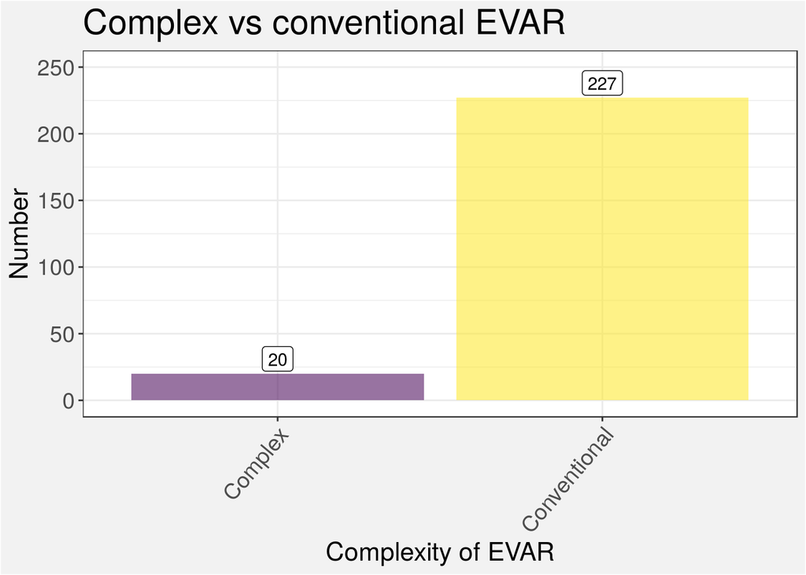

Elective EVARs; all sites, all years

Home